# Day 4: Ceres Search

Author

Kasia Kedzierska

Published

December 4, 2024

Modified

December 4, 2024

Today, we’re searching the **Ceres monitoring station** and we’re helping adorable little Elf with their word search.

Do check out the full details of the task on the official [Day 4 of Advent of Code 2024](https://adventofcode.com/2024/day/4) website – the puzzles come with a cute story.

And as per tradition, let’s set the set the scene with ChatGPT illustration of the day.

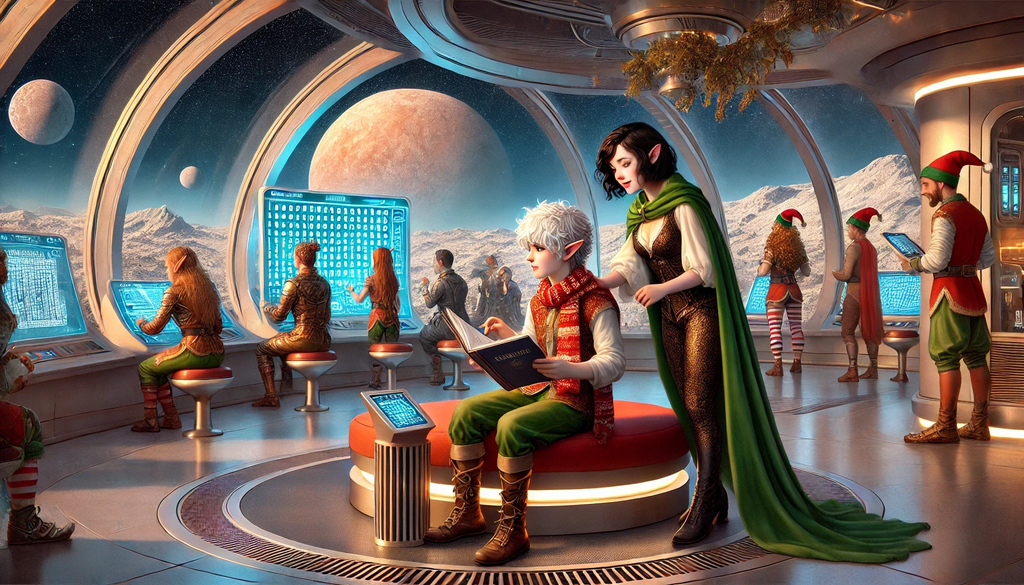

## Part 1: Searching for XMAS

The challenge is to find occurrences of the word `XMAS` in a given letter grid. The twist is that the word can appear in any direction: horizontally, vertically, or diagonally, and even in reverse order. This adds a layer of complexity as we must account for all possible orientations.

Here’s an example of a grid with all letters not spelling `XMAS` removed:

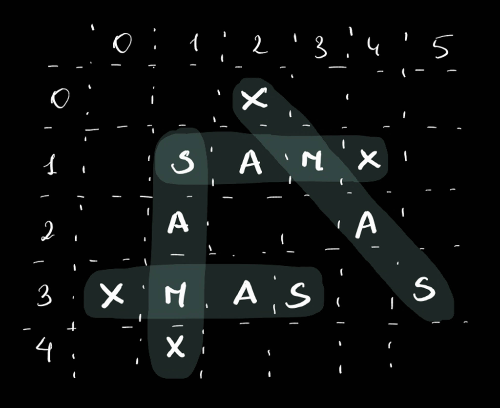

Our task is to count how many times `XMAS` appears in a provided grid, considering all the possible directions.

For example, in the grid below:

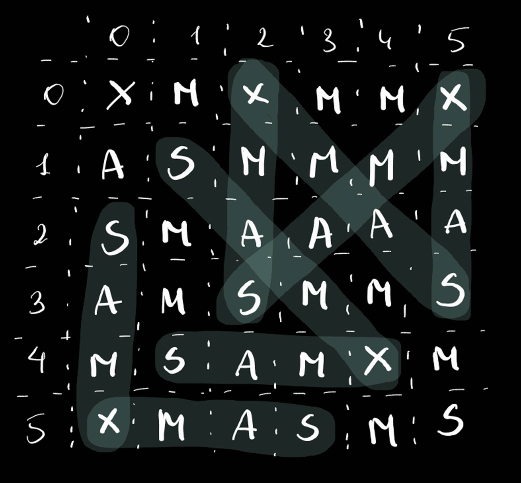

### My approach

For this one, I want to solve it in a single pass through the grid. Here’s my plan:

1. I’ll go through each character in the grid.
2. If I encounter an `X` or an `S`, I’ll add it to a dictionary to track potential matches. For each match, I’ll:
   - Note the directions to explore (`right`, `diagonal left`, `diagonal right`, and `down`).
   - Keep track of whether I’m spelling the word forward or backward.
   - Record the next letter I’m expecting to find.
3. For each position, I’ll check:
   - If it’s already being tracked in the dictionary.
   - If so, I’ll see if the letter matches what I’m expecting. If it does, I’ll update the dictionary with the next position to check.
4. By doing this, I ensure:
   - Each position is only processed once.
   - I avoid any redundant checks or unnecessary traversals.

This approach keeps things efficient and clean while letting me track progress dynamically.

**Setting up**

```python
from misc.helper import verify_answer

tiny_example = """
..X...
.SAMX.
.A..A.
XMAS.S
.X....
"""

tiny_example_answer = 4

my_example = """
XMXMMX
ASMMMM
SMAAAA
AMSMMS
MSAMXM
XMASMS
"""

my_example_answer = 8

example_input = """
MMMSXXMASM
MSAMXMSMSA
AMXSXMAAMM
MSAMASMSMX
XMASAMXAMM
XXAMMXXAMA
SMSMSASXSS
SAXAMASAAA
MAMMMXMMMM
MXMXAXMASX
"""

example_answer_p1 = 18
```

```python
from pathlib import Path


def part_one(input: str) -> int:
    xmas = "XMAS"

    if Path(input).exists():
        with open(input) as f:
            input = f.read()

    check_position = {}
    count_words = 0
    directions = [(0, 1), (1, -1), (1, 0), (1, 1)]

    for i, line in enumerate(input.strip().splitlines()):
        for j, char in enumerate(line):
            to_be_checked = check_position.pop((i, j), [])

            for schar, coord, dir in to_be_checked:
                if schar == char:
                    if char in "XS":
                        count_words += 1
                    else:
                        next_pos = (i + coord[0], j + coord[1])
                        next_char = xmas[xmas.find(char) + dir]
                        check_position.setdefault(next_pos, []).append(
                            (next_char, coord, dir)
                        )

            if char in "XS":
                direction_shift = 1 if char == "X" else -1
                for dx, dy in directions:
                    next_pos = (i + dx, j + dy)
                    next_char = xmas[xmas.find(char) + direction_shift]
                    check_position.setdefault(next_pos, []).append(
                        (next_char, (dx, dy), direction_shift)
                    )

        check_position = {
            key: val for key, val in check_position.items() if key[0] > i
        }

    return count_words
```

```python
verify_answer(part_one, tiny_example, tiny_example_answer)
```

```
✔️ That's right! The answer is 4.
```

```python
verify_answer(part_one, my_example, my_example_answer)
```

```
✔️ That's right! The answer is 8.
```

```python
verify_answer(part_one, example_input, example_answer_p1)
```

```
✔️ That's right! The answer is 18.
```

```python
%time
part_one("./inputs/Day04.txt")
```

```
CPU times: user 2 μs, sys: 0 ns, total: 2 μs
Wall time: 5.72 μs
```

```
2560
```

> That’s the right answer! You are one gold star ⭐ closer to finding the Chief Historian.

## Part 2: Searching for X-MAS

In this task, we need to find the shape `X` created by words `MAS`, like this:

[figure not shown]

For example, in the grid below there are **5** `X-MAS` shapes:

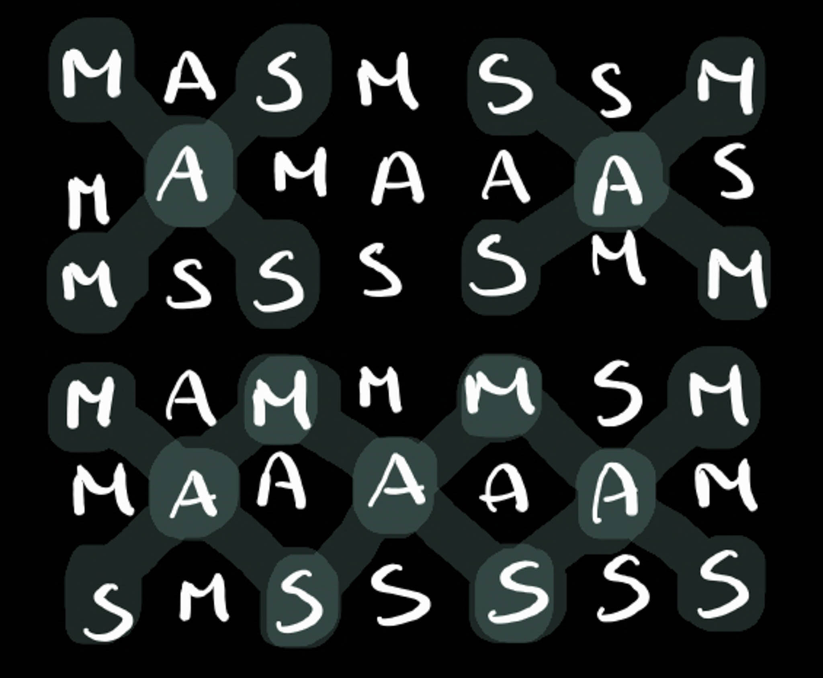

### My approach

Instead of trying to traverse the input in one pass, I’ll keep things simple by reading it to a matrix and checking each 3x3 submatrix for the `X-MAS` shape. Here’s my plan:

1. I’ll first parse the grid into a matrix format for easy access.
2. Then, I’ll loop through all possible 3x3 submatrices in the grid and check each submatrix for the `X-MAS` shape:

   For a valid shape, the following conditions must hold:
   - The center of the submatrix must be `A`.
   - The upper-right and lower-left corners must be either:
     - `M` and `S`, or
     - `S` and `M`.
   - Similarly, the upper-left and lower-right corners must be either:
     - `M` and `S`, or
     - `S` and `M`.
3. Finally, if all these conditions are satisfied, I’ll increment a counter.

This approach allows me to focus on identifying the pattern in localized regions of the grid, keeping the logic straightforward and easy to implement.

**Saving test answer**

```python
example_answer_p2 = 9

small_x_mas_example = """
MASMSSM
MAMAAAS
MSSSSMM
MAMMMSM
MAAAAAM
SMSSSSS
"""

small_x_mas_example_answer = 5
```

```python
def read_input_to_matrix(input: str) -> list:
    if Path(input).exists():
        with open(input) as f:
            input = f.read()

    output = []

    for line in input.strip().splitlines():
        output.append([c for c in line.strip()])

    return output


def part_two(input: str) -> int:
    mat = read_input_to_matrix(input)

    count_mats = 0

    for i in range(len(mat[0]) - 2):
        for j in range(len(mat) - 2):
            center = mat[j + 1][i + 1]
            top_left, bottom_right = mat[j][i], mat[j + 2][i + 2]
            top_right, bottom_left = mat[j][i + 2], mat[j + 2][i]

            cond_center = center == "A"
            cond_lr = (top_left == "M" and bottom_right == "S") or (
                top_left == "S" and bottom_right == "M"
            )
            cond_rl = (top_right == "M" and bottom_left == "S") or (
                top_right == "S" and bottom_left == "M"
            )

            if cond_center and cond_lr and cond_rl:
                count_mats += 1

    return count_mats
```

```python
verify_answer(part_two, small_x_mas_example, small_x_mas_example_answer)
```

```
✔️ That's right! The answer is 5.
```

```python
verify_answer(part_two, example_input, example_answer_p2)
```

```
✔️ That's right! The answer is 9.
```

```python
%time
part_two("./inputs/Day04.txt")
```

```
CPU times: user 1 μs, sys: 1 μs, total: 2 μs
Wall time: 1.91 μs
```

```
1910
```

> That’s the right answer! You are one gold star ⭐ closer to finding the Chief Historian.